# 190424_StatsInJulia

Doing statistics/econometrics in Julia 1.0

- Author: Tianhao Zhao
- Last Update: April 29, 2019
- Copyright: free

# Current Table of Contents

**This blog will be updated irregularly. Here is a sketch of the topics to discuss.**

**Planed Contents**:

1. Introduction
2. What Packages to Use
3. Descriptive Statistics
4. Distributions
5. Sampling & Simulation
6. Hypothesis Testing
7. Linear Regressions & GLM
8. Other Generic Regression Topics
   1. Clustering
   2. Classification
   3. PCA/Factor Analysis
   4. Mixture Models
9. Econometric Topics
   1. Time Series
   2. Panel Data Models
   3. Quantile Models
   4. Structural Models
   5. Filters
   6. MCMC
   7. Beyassian Econometrics
10. How to Develop Your Own Statistical Models in Julia

# Introduction

In another blog where I introduced how to prepare your Julia 1.0 for economic research, I roughly discussed the statistics/econometrics in Julia in the conclusion section. Though there is still a long way for Julia to go in econometrics, we can now do many fantastic jobs in statistics. This blog discusses how to do basic statistics in Julia 1.0. It depends on `JuliaStats` project and its packages. This is a project initiated by the Julia official. It is the base of the statistics in Julia language.

In Section 2, I provide a full list of the packages under `JuliaStats` project and some other packages. We will use these packages in this blog. In Section 3, I introduce how to use Julia do descriptive Statistics, e.g. histogram, QQ-plot. In Section 4, I introduce how to play with many statistical distributions in Julia. In Section 5, I introduce how to sampling on distributions or datasets. In Section 6, I introduce how to do hypothesis tests e.g. two-sample F tests. In Section 7, I introduce how to do basic regression analysis with `MultivariateStats` and `GLM` packages. In Section 8, I introduce how to do other common statistical analysis such as clustering and PCA. In Section 9, I discuss what other functions are required but not provided yet if we want to do more-specific econometric research, e.g. quantile regression and panel data models.

# What Packages to Use?

In this section, I talk about what packages to use in the next sections. About how to install Julia packages, please read my another blog. Please note, we do not use R/Python's API via `RCall`/`PyCall` (except plotting with `PyPlot`) since we are talking about the statistics in Julia. Meanwhile, this blog cannot cover every function of each package. Readers may be like to read these packages' documentations through searching their names on Github.

`JuliaStats` is a project initiated by Julia official. Its website is: [JuliaStats.org](https://juliastats.github.io/). This project aims to make Julia become powerful in statistics (well ... not specially for econometrics). It has been the foundation of many ML/DL pacakges of Julia. The reason why we mainly talk about this project is that `JuliaStats` is like `SciPy` for Python or `stats` for R. It is expected to be the foundation of Julia statistics.

There are 15 packages under `JuliaStats` project now. The following table is modified from the [documentation page](https://juliastats.github.io/) of `JuliaStats`:

| Package | Task | Mainly for |
| --- | --- | --- |
| StatsBase | Basic functionalities for statistics | Descriptive statistics; sampling; ranking; weights; correlation/auto-correlation |
| StatsModels | Interfaces for statistical models | R-style `@formula`; abstrations for statistical model development |
| DataFrames | Essential tools for tabular data | Data structure and operations for regression datasets |
| Distributions | Probability distributions | A large number of univariate/multivariate distributions; descriptive stats; moments/pdf/cdf/mgf, sampling, MLE |
| MultivariateStats | Multivariate statistical analysis | Matrix-based API for linear (e.g. LS, Lasso, Ridge) models, dimensionallity reduction, scaling, linear discriminant analysis |
| HypothesisTests | Hypothesis tests | Parametric and Nonparametric tests |
| MLBase | Swiss knife for machine learning | Data preprocessing; classifications; performance evaluation; model selectionn; cross-validation |
| Distances | Various distances between vectors |  |
| KernelDensity | Kernel density estimation | For univariate/multivariate/bivariate data; user customization of interpolation points/kernel/bandwidth |
| Clustering | Algorithms for data clustering | K-means/medoids; Affinity propagation; Performance evaluation etc. |
| GLM | Generalized linear models | R-style API |
| NMF | Nonnegative matrix factorization | NMF algorithms; NNDSVD |
| RegERMs | Lasso/Elastic Net linear and GLMs | glmnet; polynomial trend filtering; O(n) fused Lasso; Gamma Lasso |
| Klara | Markov Chain Monte Carlo (MCMC) | engine for Beyasian inference; samplers using latest techniques; user-friendly syntax for model specification; Ability to suspend and resume |
| TimeSeries | Time series analysis | Tools to represent, manipulate and apply computation to time series data |

In this blog, we talk about most of these pacakges but not all of them.

Nowadays, many tutorials make it confused that which namespaces/pacakges a function belongs to. This is awful because beginners will be totally confused. In this blog, I will explicitly mention what packages that a function belongs to when talking about it for the first time. And, I will `import` a package rather than `using` it to make its namespace private. Of course, those common packages will be used to make code clear.

Meanwhile, we use `PyPlot` as our visualization package, and do not use `Plots` as frontend. Matlab & Python users may see many familiar sentences.

# Descriptive Statistics

In this section, we talk about how to use Julia to do common descriptive statistics. This section consists of:

1. Making a table of descriptive statistics: `mean`, `std`, `qunatile` etc.
2. Plotting: histogram, kernel density, QQ-plot, pie
3. Plotting: line, bar, box, pie

Subsections 2, 3 which are about visualization are not emphasized, because they are more related to the usage of specific visualization tools (e.g. `PyPlot`) than statistical principles.

## Making a table of descriptive statistics

When introducing a dataset in paper, authors are usually required to provide a summary table like:

| Variable | N | min | 25% quantile | median | mean | std | 75% quantile | max |
| --- | --- | --- | --- | --- | --- | --- | --- | --- |
| y | 100 | -1.00 | -0.24 | -0.20 | -0.18 | 2.34 | 0.23 | 0.76 |
| x | 100 | 23.22 | 25.03 | 27.98 | 26.33 | 0.54 | 29.22 | 31.43 |

To make such a table, readers need to learn:

1. how to compute basic statistics, e.g. sample size, mean and std, for a single variable
2. how to construct or format such a table

For the two tasks, there may be some easy-APIs to automatically compute everything then do formatting. But we will finish the two jobs step by step, to get familiar with Julia's statistics.

Before Julia 0.7, common descriptive statistical methods, e.g. `mean`, are included in core Julia, which means users do not need to explicitly import/using a package to introduce them. But since v0.7, these functions are separated to a standard library `StatsBase`. (Yes, this package is one part of `JuliaStats` project) Now, we introduce this package then see several demos which show how to do basic statistics.

P.S. to explicitly display which pacakge a function belong to, we use `import` but not `using` to keep introduced packages private. But in practice, we usually `using StatsBase` to expose all exportable objects to current namespace to avoid re-writing "StatsBase" times by times

```julia
# julia 1.0
    import StatsBase

# generate a random vector (one-way Array) from a [0,1] uniform distributions; rand() & randn() are kept in core Julia
x = rand(100)
println("Please note the type of x: ",typeof(x), " which is a synonym of Vector{Float64,1}")

# compute and print basic statistics
println("mean value: ", StatsBase.mean(x) )
println("standard error: ", StatsBase.std(x) )
println("variance: ", StatsBase.var(x) )
println("kurtosis: ", StatsBase.kurtosis(x) )
println("skewness: ", StatsBase.skewness(x) )
println("5th order sample central moment: ", StatsBase.moment(x,5) )
println("min  value & its location in x: ", findmin(x) )
println("max  value & its location in x: ", findmax(x) )
println("25% quantile: ", StatsBase.quantile(x, 0.25) )
println("75% quantile: ", StatsBase.quantile(x, 0.75) )
println("median: ", StatsBase.median(x), " which is equivalent to 50% quantile: ", StatsBase.quantile(x, 0.5) )
println("mode: ", StatsBase.mode(x) )
```

```
Please note the type of x: Array{Float64,1} which is a synonym of Vector{Float64,1}
mean value: 0.48521158882357773
standard error: 0.3076766420738591
variance: 0.09466491607784558
kurtosis: -1.2816435764149026
skewness: -0.028430831233924724
5th order sample central moment: 4.362788972667082e-5
min  value & its location in x: (0.001958103627337726, 55)
max  value & its location in x: (0.9972898039542897, 36)
25% quantile: 0.17948895852651403
75% quantile: 0.7573790184326592
median: 0.5137663782501359 which is equivalent to 50% quantile: 0.5137663782501359
mode: 0.7496324372043717
```

There are several things to note:

1. `Vector{T}` is a simple presentation of one-way array `Array{T,1}`, where `T` is a wildcard denoting "type" in Julia type systems. In the same way, `Matrix{T}` is the simple presentation of two-way array `Array{T,2}`. And in Julia, `Array{T,W}` can be seen as the union set of Python's list and Matlab's array. They can do list operations also linear algebra operations.
2. finding max/min in Julia does not use `max()` and `min()` but use `findmax()` and `findmin()`. The two functions return a 2-member Tuple whose 1st member is the max/min value and the 2nd is the location of max/min in the given iterable object. By the way, `max()` and `min()` are similar to those in C/C++. They just compare two arguments and return the larger/smaller one.

Now we learn how to format a table of basic descriptive statistics. To do this job, there are two common ways:

1. using simple `Array{T,2}` structures then format it by oneself
2. using `DataFrame` to make it look like a table

First, we display a demo of using `Array{T,2}` to format your statistics.

```julia
x1 = rand(100); x2 = randn(100); # sample data, one from uniform, one from N(0,1)
stattab = [
    "Variable" "N" "min" "25% qt" "median" "mean" "std" "75% qt" "max" ;
    "x1" length(x1) findmin(x1)[1] StatsBase.quantile(x1,0.25) StatsBase.median(x1) StatsBase.mean(x1) StatsBase.std(x1) StatsBase.quantile(x1,0.75) findmax(x1)[1] ;
    "x2" length(x2) findmin(x2)[1] StatsBase.quantile(x2,0.25) StatsBase.median(x2) StatsBase.mean(x2) StatsBase.std(x2) StatsBase.quantile(x2,0.75) findmax(x2)[1] ;
]
println("The table of basic statistics in a Matrix:")
stattab
```

```
The table of basic statistics in a Matrix:
```

```
3×9 Array{Any,2}:
 "Variable"     "N"    "min"      …   "std"     "75% qt"   "max"
 "x1"        100      0.00662265     0.296445  0.696367   0.983436
 "x2"        100     -2.41295        0.948719  0.474806   2.72317
```

```julia
# or we can define a small function to make things clearer
func(x) = return [
    length(x) findmin(x)[1] StatsBase.quantile(x,0.25) StatsBase.median(x) StatsBase.mean(x) StatsBase.std(x) StatsBase.quantile(x,0.75) findmax(x)[1] ;
]

# use cat() to connect arrays on specific dim
# NOTE: dims = 1 by columns, dims = 2 by rows
stattab = cat(
    [ "Variable" "N" "min" "25% qt" "median" "mean" "std" "75% qt" "max"],
    cat( "x1", func(x1), dims = 2 ),
    cat( "x2", func(x2), dims = 2 ),
    dims = 1
);
println("The table of basic statistics in a Matrix:")
stattab
```

```
The table of basic statistics in a Matrix:
```

```
3×9 Array{Any,2}:
 "Variable"     "N"    "min"      …   "std"     "75% qt"   "max"
 "x1"        100.0    0.00662265     0.296445  0.696367   0.983436
 "x2"        100.0   -2.41295        0.948719  0.474806   2.72317
```

Now, we use a DataFrame to organize our result:

```julia
import DataFrames # private, but usually "using" in practice

# creating a DataFrame by columns:
statdframe = DataFrames.DataFrame(
    :Variable => ["x1", "x2"],
    :N => [ length(x1), size(x2)[1] ], # using size()[1] to get the size of 1st dimension
    :min => [findmin(x1)[1], findmin(x2)[1]],  # basic definition
    :qt25 => [ StatsBase.quantile(y,0.25) for y in [x1,x2] ], # python-like list comprehension
    :median => StatsBase.median.([x1,x2]), # "."-style method broadcasting
    :mean => StatsBase.mean.([x1,x2]),
    :qt75 => StatsBase.quantile.([x1,x2], 0.75),
    :max => [findmax(x1)[1], findmax(x2)[1]]
);
println("The defined data frame is: ")
statdframe
```

```
The defined data frame is:
```

|  | Variable String | N Int64 | min Float64 | qt25 Float64 | median Float64 | mean Float64 | qt75 Float64 | max Float64 |
| --- | --- | --- | --- | --- | --- | --- | --- | --- |
| 1 | x1 | 100 | 0.00662265 | 0.182114 | 0.411292 | 0.450711 | 0.696367 | 0.983436 |
| 2 | x2 | 100 | -2.41295 | -0.550101 | -0.131756 | -0.0865205 | 0.474806 | 2.72317 |

## Plotting: histogram, QQ-plot, and density curve

In the section of descriptive statistics, authors usually provide illustrations about some important variables (e.g. dependent variable). This subsection discusses how to make common diagrams in Julia. Of course, using `PyPlot` API. But please note, I will not discuss this topic much because it depends on what visualization tool you use.

*Note: Readers with experience in python may skip this subsection because the usage of `PyPlot` is very similar to `matplotlib.pyplot`. However, there are some subtle differences raised by the different realizations of Julia and python's OO mechanism.*

### Histogram & Density Curve

One of the most common diagram used in descriptive statistics is single-variable histogram. Sometimes, people also like to draw a histogram with a kernel-density curve. Actually, both histogram & kernel-density, as the most simple nonparametric estimations, need to be estimated. But here we do not discuss this topic because `PyPlot` automatically does this job unless we need some custom histogram (e.g. censored histogram). If you wanna learn how to make your custom colorful histograms, please refer to this [page](https://towardsdatascience.com/histograms-and-density-plots-in-python-f6bda88f5ac0).

Here is a demo to draw histograms with an estimated kernel-density curve in Julia. You need the `KernelDensity` package of `JuliaStats` project.

```julia
using PyPlot  # using PyPlot
    import KernelDensity  # under JuliaStats project
```

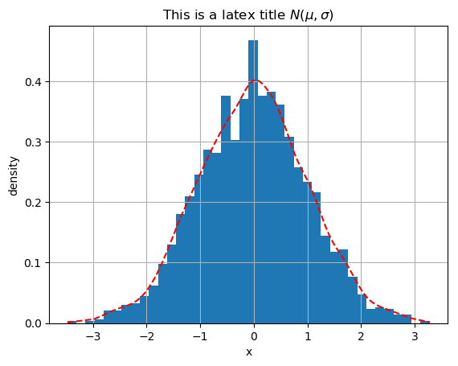

[output not shown]

```julia
x = randn(2000) # sample data, a vector
kde_x = KernelDensity.kde(x) # univariate kernel estimation, default settings

figure()
    hist(x, 40, density = true); # 40 specifies how many sections to use, density = true displays density rather than frequency
    plot(sort(x),KernelDensity.pdf(kde_x,sort(x)),"--r") # sort x then use KernelDensity.pdf() to get the interpolated pdf value at x points
    # NOTE: sort x because plot() connect points according to their position in x
    xlabel("x"); ylabel("density"); grid(true);
    title(L"This is a latex title $N(\mu,\sigma)$");  # this is how to use latex string in PyPlot: L"string"
```

In this demo, I `import KernelDensity` rather than `using` it because I wanna let readers know which functions belong to `KernelDensity`. We can see `KernelDensity.kde` function estimates the kernel density of vector `x` with default settings (e.g. the bandwidth), like the `density()` function in R language. But please note, the returned object by `KernelDensity.kde()` is an interpolation-like object whose density value can be evaluated at a specific `x0` via `KernelDensity.pdf(kde_x,x0)`. Meanwhile, `KernelDensity` provides full functions for kernel estimation, users may read its [documentations](https://github.com/JuliaStats/KernelDensity.jl) for more usage of this package.

By the way, readers are recommended to use `NovDist.LatinHyperCube()` in my another blog to quickly rebuild a distribution, esp. when they do Monte-Carlo based estimations.